# Franco_García_T2

Enrique Franco

17/2/2022

1. Considera las siguientes cantidades discute y justifica qué tipo de distribución de probabilidad pueden tener las siguientes variables:
1. **El número (talla) de calzado de adultos varones en México.**

   R = Se va a observar una distribución Gaussiana o de campana, esto se debe a que gran parte de la población va a encontrarse entre las tallas del 26 al 27, mientras que muy pocos hombres van a calzar por debajo del numero 26 y de igual manera pocos calzaran por encima del 27
2. **La distribución de habitantes en asentamientos humanos de México.**

   R = Es una distribución logarítmica gracias a que el numero de personas que habitan ciudades año con año aumenta, si comparáramos la cantidad de habitantes que tenia Querétaro en el 2010 con la cantidad de habitantes que tiene este año podremos ver un crecimiento abismal en el cual en ningún momento existió una decreció, dándonos una característica distribución logarítmica.
3. **La velocidad promedio de los automóviles en Bernardo Quintana a las 9 de la mañana en un día laborable.**

   R = Esta va a ser una distribución de cola larga, esto se debe a que usualmente a esa hora existe mucho trafico sobre Bernardo Quintana, entonces gran cantidad de personas van a ir a una velocidad lenta o no muy rápida y solo muy pocos van a poder ir rápido gracias a que van rebasando o buscando huecos entre los carros como pueden ser motociclistas.
4. **La velocidad promedio de los automóviles en Bernardo Quintana a las 3 de la mañana.**

   R = Para este caso seguramente se tendrá una distribución de probabilidad Gaussiana, esto debido a que la gran mayoría de coches iran a 80 km/h que es el limite de velocidad, sin embargo, también tendremos algunas personas que irán mucho más rápido que esa velocidad y otras que irán más lento. Esto va a hacer que se forme la característica campana de una distribución Gaussiana, en donde tenemos a la mayoría de la población concentrada en el centro de la gráfica y en los extremos presentamos “outliers” los cuales serán individuos dentro de la población que salen de la normalidad.
2. Supongamos que tenemos dos nodos (A,B) en una red. El nodo A y B tiene el mismo degree, pero el A tiene un coeficiente de clusterización de 1 y el nodo B un coeficiente bajo.Dibuja está situación y explica cuál sería una mejor diana si quieres eliminarlos y afectar a la red.

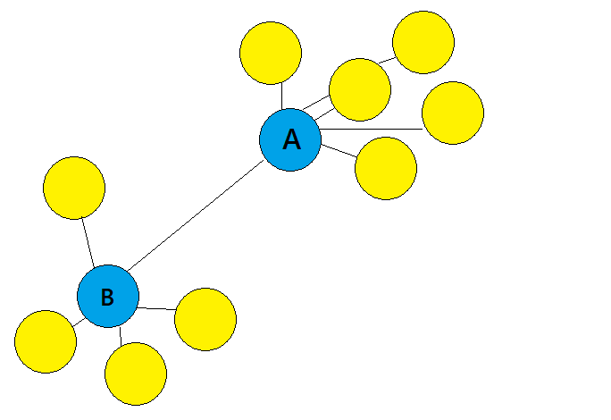

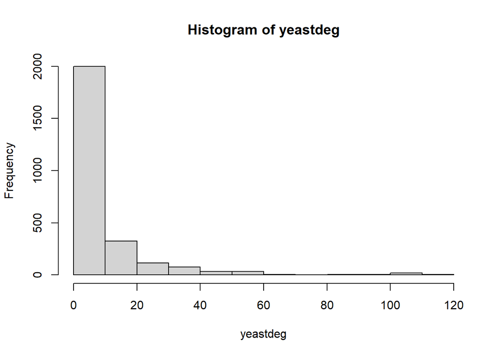

```r
library(igraph)
library(igraphdata)
data("yeast") #Cargo las librerias que voy a utilizar así como la base de datos
yeastdeg <- degree(yeast) #Con esta funcion visualizo las conexiones existentes entre las proteinas
hist(yeastdeg) #Genero un histograma a partir de dichas conexiones
```

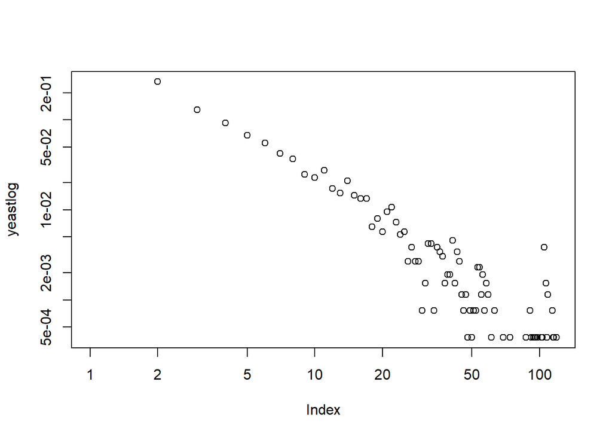

```r
yeastlog <- degree_distribution(yeast) #Con esto lo vi a escala logaritmica
plot(yeastlog, log = "xy") #Lo grafico
```

DISCUSION: Podemos observar que para el histograma tenemos una distribucion de cola larga, esto se debe a que muy pocas proteínas tienen gran cantidad de conexiones y muchas proteínas tienen pocas conexiones, por otro lado, para la escala logaritmica al momento de que se grafica podemos presenciar una linea en diagonal bien formada con algo de ruido. b. Grafique el boxplot de la distribución de conectividades y discute tu resultado.

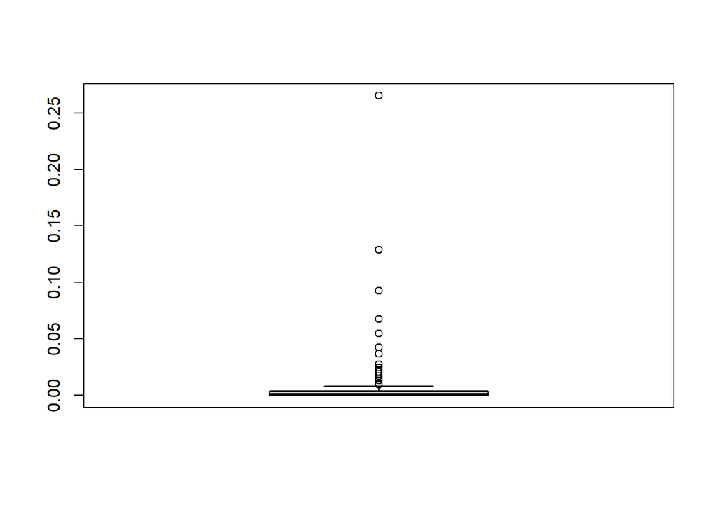

```r
yeastlog <- degree_distribution (yeast) #distribucion a escala logatitmica
boxplot (yeastlog) #realizamos un boxplot
```

DISCUSION: De igual manera que como ocurre con el histograma vamos a poder observar que la mayoría de las proteínas se agrupan en los numeros inferiores y son pocos los outliers que podemos observar que sobrepasan el 0.05

```r
yeastdeg <- degree(yeast) #Nuevamente observo las conexiones existentes entre las proteinas
sort (yeastdeg, decreasing = T) #De esta manera ordeno de forma descendente dichas conexiones
```

```
##   YPR110C   YPL131W   YNL178W   YIL021W   YOL127W   YJL063C   YBR283C   YLR378C
##       118       115       114       113       113       108       108       108
##   YMR260C   YBR251W   YGL123W   YNL284C   YGL103W   YOL040C   YGR034W   YDL191W
##       107       106       106       106       106       104       104       104
##   YDL136W   YGR220C   YNR037C   YOR063W   YIL018W   YLR344W   YEL050C YPL183W-A
##       104       104       104       104       104       104       104       102
##   YDR041W   YJR113C   YML010W   YBL038W   YLR075W   YGL068W   YHL015W   YNL189W
##       101        97        95        94        93        91        90        90
##   YJR123W   YBL004W   YDL014W   YLR175W   YBL092W   YNL132W   YDR101C   YNR016C
##        86        73        68        62        62        60        58        58
##   YIL147C   YPR010C   YJL109C   YER016W   YBR257W   YMR290C   YDL029W   YER006W
##        58        57        57        57        57        56        56        55
##   YDR496C   YGR103W YBR084C-A   YBL027W   YKL009W   YHR203C   YJR145C   YHR052W
##        55        55        55        55        54        54        54        53
##   YPR016C   YGR090W   YBR146W   YDR237W   YNL271C   YOR116C   YPL093W   YPR187W
##        53        53        53        53        53        52        52        52
##   YOR207C   YMR310C   YGR283C   YNL002C   YPL012W   YMR049C   YNL306W   YOR341W
##        52        52        52        51        51        50        50        49
##   YGL059W   YIL042C   YML025C   YOL077C   YOR272W   YGL205W   YGL211W   YBR234C
##        48        48        47        46        46        46        45        45
##   YDR116C   YNL061W   YHR147C   YDL140C   YPL043W   YGR145W   YMR158W   YDL061C
##        44        44        44        43        43        43        43        43
##   YPR166C   YLR388W   YDR036C   YGL147C   YNL067W   YLR367W   YJL190C   YGR085C
##        43        43        42        42        42        42        42        42
##   YPR102C   YBR048W   YKL173W   YMR188C   YOR151C   YMR125W   YDR025W   YLR197W
##        42        42        42        41        41        41        41        40
##   YML026C   YKL170W   YOR206W   YDR450W   YDR012W   YNL177C   YJL177W   YKL180W
##        40        40        40        40        40        40        40        40
##   YBR031W   YER117W   YBL087C   YDR127W   YBR208C   YNL081C   YCR031C   YJL191W
##        40        40        40        39        39        39        39        39
##   YHR197W   YPL126W   YKR081C   YOR150W   YIL133C   YDR394W   YLR340W   YNL069C
##        38        38        38        38        38        37        37        37
##   YKL113C   YLR409C   YDL185W   YKL145W   YDR449C   YPL231W   YMR143W   YDL083C
##        37        36        36        36        36        36        36        36
##   YPL212C   YKL104C   YEL054C   YDR418W   YPL220W   YGL135W   YHR148W   YNL292W
##        36        35        35        35        35        35        35        35
##   YGR118W   YNL185C   YLL008W   YNR036C   YPR132W   YDL202W   YKL192C   YML049C
##        35        35        34        34        34        34        34        34
##   YFL001W   YGL063W   YDR117C   YBR247C   YDR337W   YER029C   YBR154C   YLR423C
##        34        34        34        34        33        33        32        32
```

[output cut: 601 more lines]

```
##         1         1         1         1         1         1         1         1
##   YMR284W   YGL027C   YGR098C   YBL069W   YHR010W   YPR116W   YDR369C   YDR217C
##         1         1         1         1         1         1         1         1
##   YBR215W   YOL068C   YOR025W   YMR224C   YNL171C   YOR160W   YAL026C   YLR425W
##         1         1         1         1         1         1         1         1
##   YNL289W   YMR299C   YOR153W   YKR047W   YIL159W   YDL117W   YLR381W   YJR053W
##         1         1         1         1         1         1         1         1
##   YDR289C   YBR095C   YBR107C   YNL170W   YHR191C   YBR231C   YNL215W   YNL307C
##         1         1         1         1         1         1         1         1
##   YML016C   YCL016C   YJR143C   YOR321W   YKL092C   YLR372W   YOR027W   YER068W
##         1         1         1         1         1         1         1         1
##   YER122C   YKL020C   YDR351W   YLR433C   YKL190W   YLL050C   YLR235C   YNL098C
##         1         1         1         1         1         1         1         1
##   YMR060C
##         1
```

```r
conex <- sort(yeastdeg, decreasing = T) [1:10]
degree_distribution(yeast)
```

```
##   [1] 0.0000000000 0.2651891479 0.1287734047 0.0924722965 0.0676346962
##   [6] 0.0550248376 0.0424149790 0.0366832251 0.0248376003 0.0229270157
##  [11] 0.0275124188 0.0171952618 0.0152846771 0.0210164310 0.0145204433
##  [16] 0.0133740925 0.0133740925 0.0064959878 0.0080244555 0.0057317539
##  [21] 0.0095529232 0.0106992740 0.0072602216 0.0053496370 0.0057317539
##  [26] 0.0026748185 0.0038211693 0.0026748185 0.0026748185 0.0007642339
##  [31] 0.0015284677 0.0042032862 0.0042032862 0.0007642339 0.0038211693
##  [36] 0.0034390524 0.0030569354 0.0015284677 0.0019105846 0.0019105846
##  [41] 0.0045854031 0.0015284677 0.0034390524 0.0026748185 0.0011463508
##  [46] 0.0007642339 0.0011463508 0.0003821169 0.0007642339 0.0003821169
##  [51] 0.0007642339 0.0007642339 0.0022927016 0.0022927016 0.0011463508
##  [56] 0.0019105846 0.0007642339 0.0015284677 0.0011463508 0.0000000000
##  [61] 0.0003821169 0.0000000000 0.0007642339 0.0000000000 0.0000000000
##  [66] 0.0000000000 0.0000000000 0.0000000000 0.0003821169 0.0000000000
##  [71] 0.0000000000 0.0000000000 0.0000000000 0.0003821169 0.0000000000
##  [76] 0.0000000000 0.0000000000 0.0000000000 0.0000000000 0.0000000000
##  [81] 0.0000000000 0.0000000000 0.0000000000 0.0000000000 0.0000000000
##  [86] 0.0000000000 0.0003821169 0.0000000000 0.0000000000 0.0000000000
##  [91] 0.0007642339 0.0003821169 0.0000000000 0.0003821169 0.0003821169
##  [96] 0.0003821169 0.0000000000 0.0003821169 0.0000000000 0.0000000000
## [101] 0.0000000000 0.0003821169 0.0003821169 0.0000000000 0.0038211693
## [106] 0.0000000000 0.0015284677 0.0003821169 0.0011463508 0.0000000000
## [111] 0.0000000000 0.0000000000 0.0000000000 0.0007642339 0.0003821169
## [116] 0.0003821169 0.0000000000 0.0000000000 0.0003821169
```

4. **Calcule el degree máximo de la red.**

```r
degree(yeast) #Con esta funcion calculo el degree
```

[output not shown]

[output cut: 601 more lines]

```
##         1         1         1         1         1         1         1         1
##   YHR010W   YPR116W   YDR369C   YGL163C   YDR217C   YBR215W   YOL068C   YOR025W
##         1         1         1         2         1         1         1         1
##   YMR224C   YNL171C   YOR160W   YAL026C   YLR425W   YNL289W   YMR299C   YOR153W
##         1         1         1         1         1         1         1         1
##   YKR047W   YIL159W   YOR058C   YDR149C   YDL117W   YLR381W   YJR053W   YDR289C
##         1         1         2         2         1         1         1         1
##   YBR095C   YBR107C   YNL170W   YHR191C   YBR231C   YNL215W   YNL307C YML095C-A
##         1         1         1         1         1         1         1         3
##   YML016C   YCL016C   YJR143C   YOR321W   YKL092C   YLR372W   YOR027W   YER068W
##         1         1         1         1         1         1         1         1
##   YER122C   YKL020C   YDR351W   YLR433C   YKL190W   YLL050C   YLR235C   YNL098C
##         1         1         1         1         1         1         1         1
##   YMR060C
##         1
```

5. **Calcule el diámetro**

```r
diameter(yeast)#Con esta funcion puedo observar el diametro
```

```
## [1] 15
```

6. **La trayectoria más larga.**

```r
distance_table (yeast) #Con esto puedo calcular la longitud de las distancias de todos los caminos mas cortos entre los vertices de la red
```

```
## $res
##  [1]  11855  67910 276506 670068 786151 550965 274661 114390  43508  16152
## [11]   5473   1378    306     56     16
##
## $unconnected
## [1] 603641
```